# GNET - 4 elements - basic analysis

# GNET - 4 elements

This is the analysis of a simplified version of the Graded Novelty Encoding Task (GNET). The original GNET used stimuli composed of five elements and six colors. To improve performance, the task was simplified by reducing stimuli to four elements (GNET4E) and three colors.

As in the original task, stimuli were algorithmically generated, allowing precise comparison between stimuli. The difference between the stimulus presented and other stimuli (several comparisons are used) is a proxy for novelty.

During familiarization, participants learned a set of 5 stimuli During the study phase, they differentiated between these and novel stimuli. During the test phase, the performed a recognition memory test for the novels intermixed with distractors. - Novels and distractors were balanced.

In the original GNET, recognition performance tended to increase monotonically with difference to familiars In the GNET4E participants showed their highest categorization performance for stimuli at intermediate levels of difference.

## Participant level calculated variables

## Exclusions

0 runs were not completed or were duplicates.

We excluded 3 participants due to low performance in the study phase. We calculated confidence intervals for the proportion of endorsed items that were previously studied (“old”) and excluded participants whose lower confidence bound fell below 0.33.

We excluded 2 participants due to missed responses in the test phase (> 20 missing responses).

This left 50 participants in the analysis.

## Demography

The sample had a mean (± SD) age of 22.02 ± 4.821254.

The sample contained 45 women.

# Analysis

## Study phase

ANOVA to compare the rejection rate for each difference category; plot shows the prototype recog rate also.

```
## Anova Table (Type 3 tests)
##
## Response: crrate
##     Effect           df  MSE         F  ges p.value
## 1 stimtype 2.72, 133.45 0.02 28.56 *** .175   <.001
## ---
## Signif. codes:  0 '***' 0.001 '**' 0.01 '*' 0.05 '+' 0.1 ' ' 1
##
## Sphericity correction method: GG
```

```
##  contrast estimate     SE df t.ratio p.value
##  D1 - D2    -0.072 0.0187 49  -3.841  0.0031
##  D1 - D3    -0.098 0.0252 49  -3.896  0.0026
##  D1 - D4    -0.142 0.0198 49  -7.167 <0.0001
##  D1 - D5    -0.220 0.0300 49  -7.342 <0.0001
##  D2 - D3    -0.026 0.0193 49  -1.345  0.6652
##  D2 - D4    -0.070 0.0167 49  -4.186  0.0011
##  D2 - D5    -0.148 0.0249 49  -5.933 <0.0001
##  D3 - D4    -0.044 0.0196 49  -2.243  0.1816
##  D3 - D5    -0.122 0.0211 49  -5.795 <0.0001
##  D4 - D5    -0.078 0.0174 49  -4.471  0.0004
##
## P value adjustment: tukey method for comparing a family of 5 estimates
```

```
##  contrast  estimate     SE df t.ratio p.value
##  linear       0.510 0.0677 49   7.528 <0.0001
##  quadratic    0.030 0.0475 49   0.632  0.5305
##  cubic        0.080 0.0360 49   2.221  0.0310
##  quartic     -0.048 0.1140 49  -0.420  0.6764
```

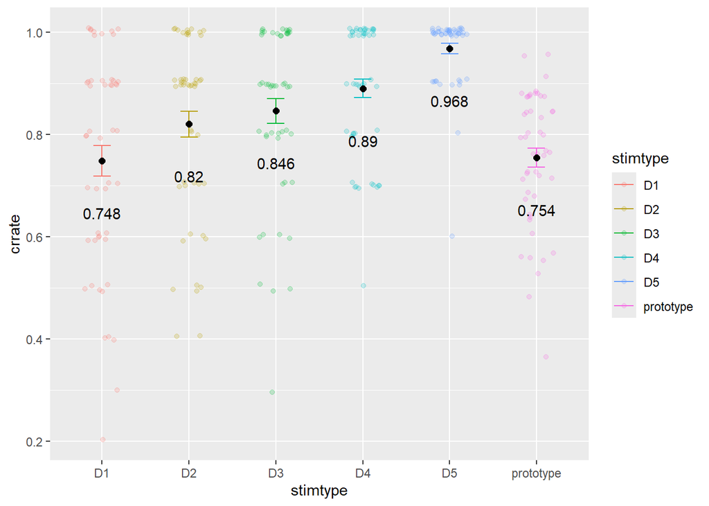

## Test phase

```
##
##  Paired t-test
##
## data:  a and b
## t = 3.1141, df = 249, p-value = 0.002061
## alternative hypothesis: true mean difference is not equal to 0
## 95 percent confidence interval:
##  0.1396684 0.6203316
## sample estimates:
## mean difference
##            0.38
```

```
##
## Cohen's d
##
## d estimate: 0.1727688 (negligible)
## 95 percent confidence interval:
##      lower      upper
## 0.06295669 0.28258087
```

```
##
##  Shapiro-Wilk normality test
##
## data:  d
## W = 0.96992, p-value = 3.954e-05
```

```
## [1] "Correct recognition for familiars in test"
```

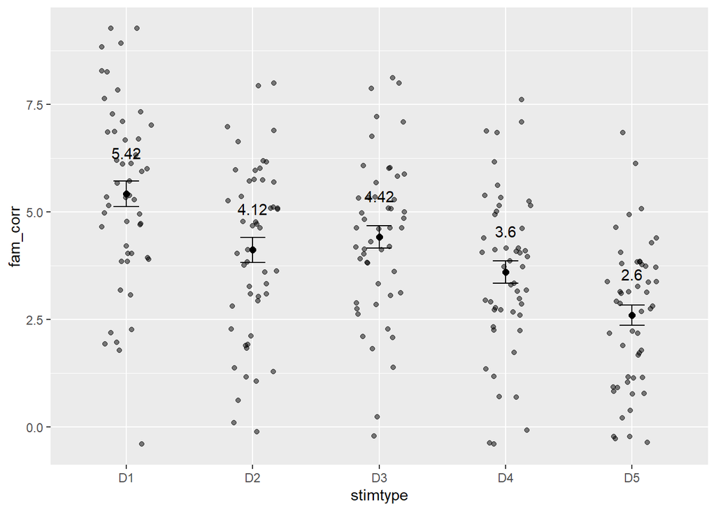

```
## [1] "False alarm for novels in test"
```

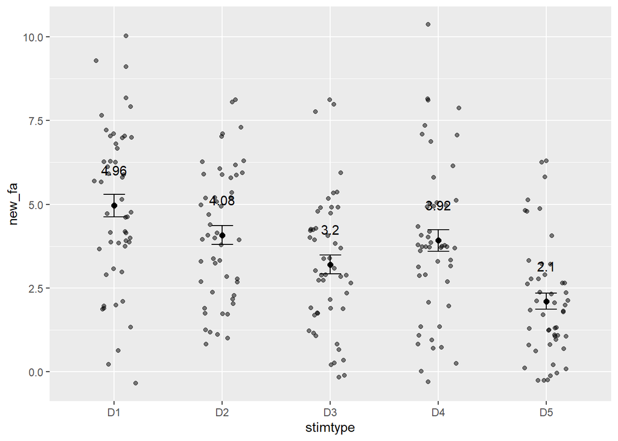

```
## [1] "ANOVA with correct recognition minus false alarm by category"
```

```
## Anova Table (Type 3 tests)
##
## Response: CorrectedRecognitions
##     Effect           df  MSE       F  ges p.value
## 1 stimtype 3.52, 172.63 4.03 4.69 ** .072    .002
## ---
## Signif. codes:  0 '***' 0.001 '**' 0.01 '*' 0.05 '+' 0.1 ' ' 1
##
## Sphericity correction method: GG
```

```
##  contrast estimate    SE df t.ratio p.value
##  D1 - D2      0.42 0.431 49   0.975  0.8649
##  D1 - D3     -0.76 0.391 49  -1.942  0.3094
##  D1 - D4      0.78 0.402 49   1.939  0.3112
##  D1 - D5     -0.04 0.364 49  -0.110  1.0000
##  D2 - D3     -1.18 0.398 49  -2.968  0.0357
##  D2 - D4      0.36 0.357 49   1.010  0.8497
##  D2 - D5     -0.46 0.345 49  -1.331  0.6732
##  D3 - D4      1.54 0.431 49   3.576  0.0068
##  D3 - D5      0.72 0.336 49   2.145  0.2181
##  D4 - D5     -0.82 0.290 49  -2.832  0.0500
##
## P value adjustment: tukey method for comparing a family of 5 estimates
```

```
##  contrast  estimate    SE df t.ratio p.value
##  linear       -0.28 0.825 49  -0.340  0.7357
##  quadratic    -0.24 0.906 49  -0.265  0.7922
##  cubic         0.76 0.785 49   0.968  0.3379
##  quartic       9.40 2.590 49   3.635  0.0007
```

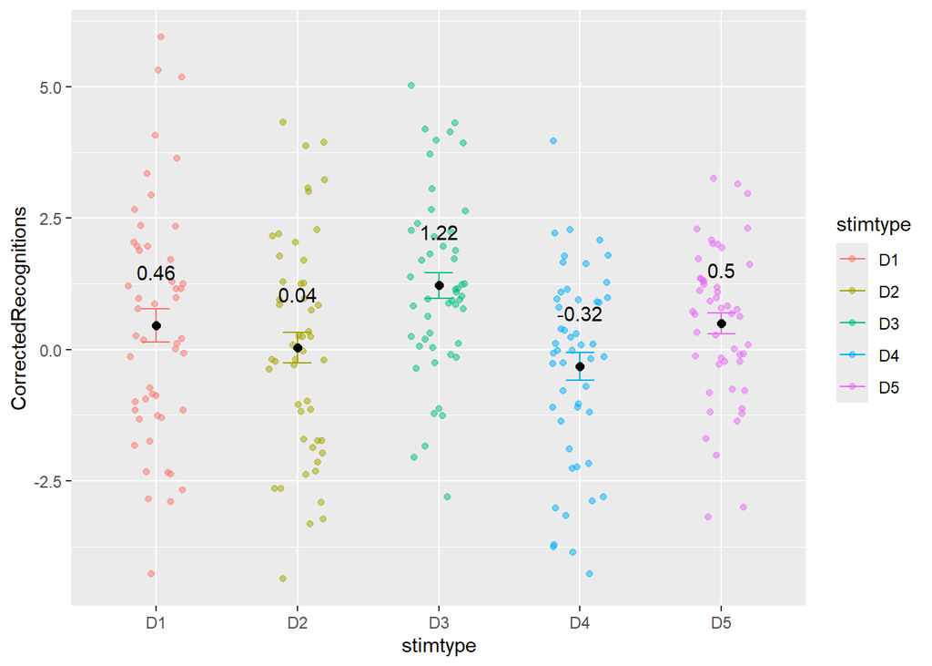

```
## [1] "ANOVA with correct rejection minus misses by category"
```

```
## Anova Table (Type 3 tests)
##
## Response: CorrectedRejections
##     Effect           df  MSE      F  ges p.value
## 1 stimtype 3.28, 160.64 5.13 3.65 * .056    .011
## ---
## Signif. codes:  0 '***' 0.001 '**' 0.01 '*' 0.05 '+' 0.1 ' ' 1
##
## Sphericity correction method: GG
```

```
##  contrast estimate    SE df t.ratio p.value
##  D1 - D2      0.38 0.463 49   0.820  0.9231
##  D1 - D3     -0.84 0.438 49  -1.916  0.3225
##  D1 - D4      0.62 0.469 49   1.323  0.6782
##  D1 - D5      0.06 0.386 49   0.155  0.9999
##  D2 - D3     -1.22 0.394 49  -3.095  0.0257
##  D2 - D4      0.24 0.342 49   0.701  0.9553
##  D2 - D5     -0.32 0.353 49  -0.907  0.8928
##  D3 - D4      1.46 0.490 49   2.979  0.0347
##  D3 - D5      0.90 0.408 49   2.204  0.1954
##  D4 - D5     -0.56 0.318 49  -1.759  0.4087
##
## P value adjustment: tukey method for comparing a family of 5 estimates
```

```
##  contrast  estimate    SE df t.ratio p.value
##  linear       -0.36 0.877 49  -0.411  0.6832
##  quadratic    -0.80 1.120 49  -0.715  0.4779
##  cubic         0.42 0.749 49   0.560  0.5778
##  quartic       8.98 2.820 49   3.184  0.0025
```

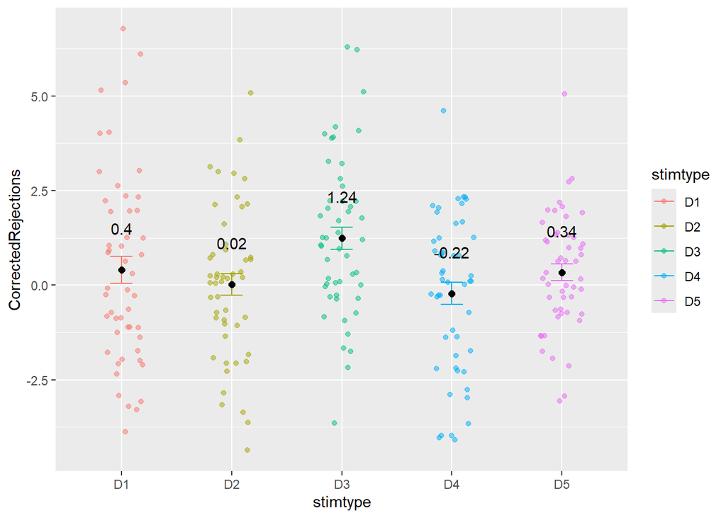

```
## [1] "ANOVA with overall corrected categorization score"
```

```
## Anova Table (Type 3 tests)
##
## Response: OCCategorizations
##     Effect           df   MSE       F  ges p.value
## 1 stimtype 3.39, 166.15 17.45 4.30 ** .065    .004
## ---
## Signif. codes:  0 '***' 0.001 '**' 0.01 '*' 0.05 '+' 0.1 ' ' 1
##
## Sphericity correction method: GG
```

```
##  contrast estimate    SE df t.ratio p.value
##  D1 - D2      0.80 0.875 49   0.914  0.8901
##  D1 - D3     -1.60 0.809 49  -1.977  0.2921
##  D1 - D4      1.40 0.860 49   1.628  0.4873
##  D1 - D5      0.02 0.733 49   0.027  1.0000
##  D2 - D3     -2.40 0.775 49  -3.096  0.0257
##  D2 - D4      0.60 0.675 49   0.889  0.8996
##  D2 - D5     -0.78 0.681 49  -1.146  0.7812
##  D3 - D4      3.00 0.904 49   3.319  0.0141
##  D3 - D5      1.62 0.731 49   2.216  0.1912
##  D4 - D5     -1.38 0.591 49  -2.335  0.1514
##
## P value adjustment: tukey method for comparing a family of 5 estimates
```

```
##  contrast  estimate   SE df t.ratio p.value
##  linear       -0.64 1.67 49  -0.384  0.7026
##  quadratic    -1.04 1.99 49  -0.523  0.6033
##  cubic         1.18 1.48 49   0.799  0.4284
##  quartic      18.38 5.32 49   3.453  0.0012
```

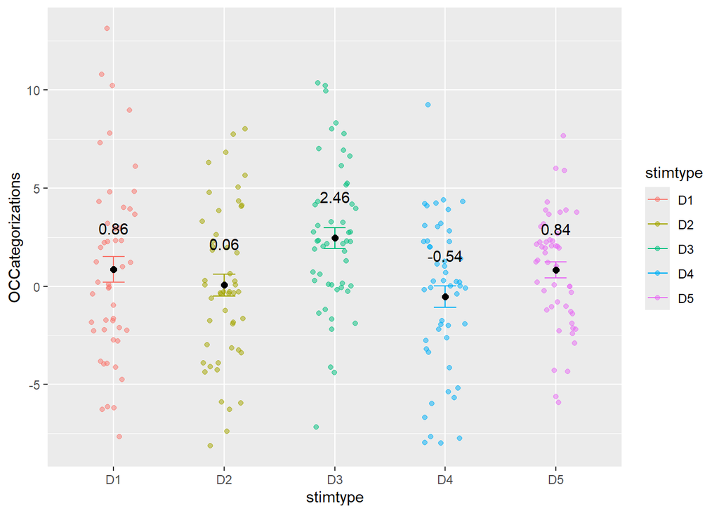

### Mixed models

## Mixed models

```
## Generalized linear mixed model fit by maximum likelihood (Laplace
##   Approximation) [glmerMod]
##  Family: binomial  ( logit )
## Formula: rt_resp ~ stimtype * test_quality + (1 | workerId)
##    Data: tdlmm
## Control: glmerControl(optCtrl = list(xtol_abs = 1e-08, ftol_abs = 1e-08,
##     maxeval = 1e+05))
##
##       AIC       BIC    logLik -2*log(L)  df.resid
##    5967.9    6039.2   -2973.0    5945.9      4797
##
## Scaled residuals:
##     Min      1Q  Median      3Q     Max
## -4.3587 -0.9446  0.4841  0.7939  2.4177
##
## Random effects:
##  Groups   Name        Variance Std.Dev.
##  workerId (Intercept) 0.475    0.6892
## Number of obs: 4808, groups:  workerId, 50
##
## Fixed effects:
##                            Estimate Std. Error z value Pr(>|z|)
## (Intercept)                 -0.2633     0.1373  -1.918  0.05510 .
## stimtypeD2                   0.5768     0.1368   4.216 2.48e-05 ***
## stimtypeD3                   0.4467     0.1364   3.276  0.00105 **
## stimtypeD4                   0.8303     0.1382   6.008 1.88e-09 ***
## stimtypeD5                   1.3821     0.1439   9.604  < 2e-16 ***
## test_qualitynew              0.1978     0.1363   1.451  0.14670
## stimtypeD2:test_qualitynew  -0.1880     0.1932  -0.973  0.33065
## stimtypeD3:test_qualitynew   0.3855     0.1949   1.978  0.04797 *
## stimtypeD4:test_qualitynew  -0.3318     0.1942  -1.709  0.08751 .
## stimtypeD5:test_qualitynew   0.0845     0.2069   0.408  0.68301
## ---
## Signif. codes:  0 '***' 0.001 '**' 0.01 '*' 0.05 '.' 0.1 ' ' 1
##
## Correlation of Fixed Effects:
##             (Intr) stmtD2 stmtD3 stmtD4 stmtD5 tst_ql stD2:_ stD3:_ stD4:_
## stimtypeD2  -0.497
## stimtypeD3  -0.498  0.501
## stimtypeD4  -0.492  0.495  0.497
## stimtypeD5  -0.473  0.477  0.478  0.473
## test_qltynw -0.499  0.501  0.503  0.496  0.477
## stmtypD2:t_  0.352 -0.707 -0.354 -0.350 -0.336 -0.705
## stmtypD3:t_  0.349 -0.349 -0.699 -0.346 -0.332 -0.699  0.493
## stmtypD4:t_  0.350 -0.352 -0.353 -0.711 -0.335 -0.702  0.495  0.490
## stmtypD5:t_  0.328 -0.330 -0.331 -0.326 -0.691 -0.659  0.464  0.461  0.462
## optimizer (Nelder_Mead) convergence code: 0 (OK)
## unused control arguments ignored
```

```
## You are calculating adjusted predictions on the population-level (i.e.
##   `type = "fixed"`) for a *generalized* linear mixed model.
##   This may produce biased estimates due to Jensen's inequality. Consider
##   setting `bias_correction = TRUE` to correct for this bias.
##   See also the documentation of the `bias_correction` argument.
```

```
## Ignoring unknown labels:
## • linetype : "test_quality"
## • shape : "test_quality"
```

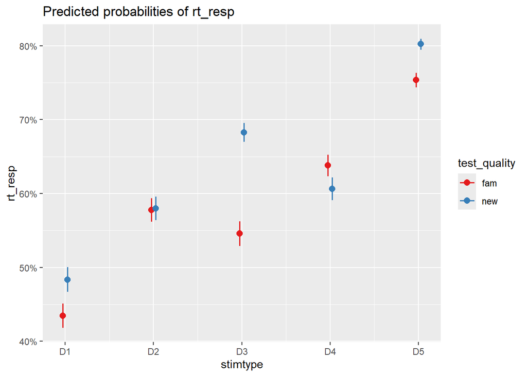

```
## $emmeans
## stimtype = D1:
##  test_quality  emmean    SE  df asymp.LCL asymp.UCL
##  fam          -0.2633 0.137 Inf   -0.5324   0.00574
##  new          -0.0655 0.137 Inf   -0.3340   0.20291
##
## stimtype = D2:
##  test_quality  emmean    SE  df asymp.LCL asymp.UCL
##  fam           0.3135 0.137 Inf    0.0440   0.58298
##  new           0.3233 0.138 Inf    0.0535   0.59310
##
## stimtype = D3:
##  test_quality  emmean    SE  df asymp.LCL asymp.UCL
##  fam           0.1834 0.137 Inf   -0.0852   0.45196
##  new           0.7666 0.141 Inf    0.4912   1.04201
##
## stimtype = D4:
##  test_quality  emmean    SE  df asymp.LCL asymp.UCL
##  fam           0.5670 0.139 Inf    0.2948   0.83920
##  new           0.4330 0.138 Inf    0.1631   0.70289
##
## stimtype = D5:
##  test_quality  emmean    SE  df asymp.LCL asymp.UCL
##  fam           1.1188 0.144 Inf    0.8356   1.40195
##  new           1.4010 0.150 Inf    1.1061   1.69597
##
## Results are given on the logit (not the response) scale.
## Confidence level used: 0.95
##
## $contrasts
## stimtype = D1:
##  contrast  estimate    SE  df z.ratio p.value
##  fam - new -0.19778 0.136 Inf  -1.451  0.1467
##
## stimtype = D2:
##  contrast  estimate    SE  df z.ratio p.value
##  fam - new -0.00979 0.137 Inf  -0.071  0.9430
##
## stimtype = D3:
##  contrast  estimate    SE  df z.ratio p.value
##  fam - new -0.58323 0.139 Inf  -4.184 <0.0001
##
## stimtype = D4:
##  contrast  estimate    SE  df z.ratio p.value
##  fam - new  0.13401 0.138 Inf   0.969  0.3326
##
## stimtype = D5:
##  contrast  estimate    SE  df z.ratio p.value
##  fam - new -0.28228 0.156 Inf  -1.813  0.0699
##
## Results are given on the log odds ratio (not the response) scale.
```

```
## Ignoring unknown labels:
## • linetype : "test_quality"
## • shape : "test_quality"
```

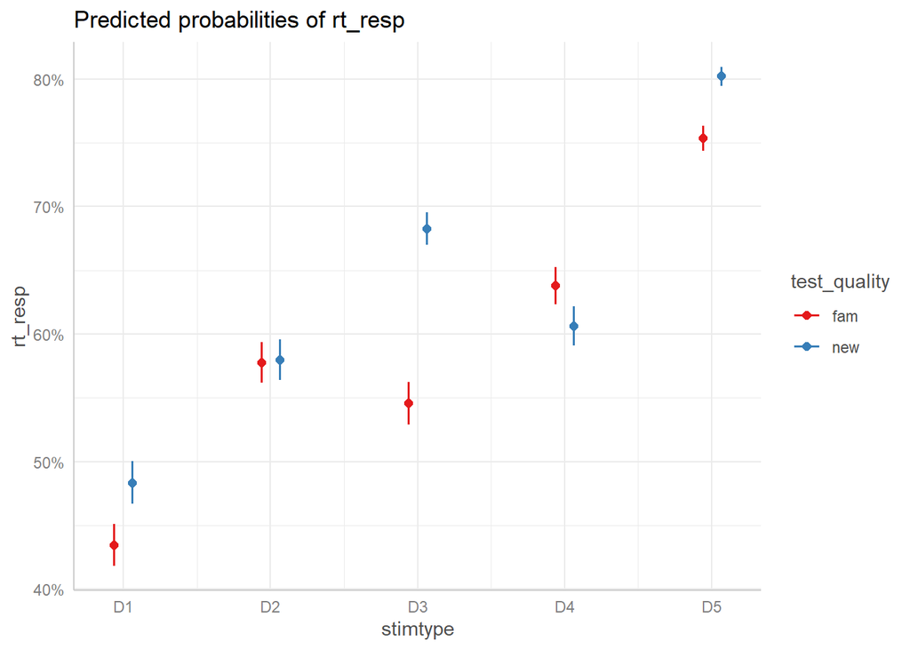

```
## NOTE: Results may be misleading due to involvement in interactions
```

```
##  contrast  estimate    SE  df z.ratio p.value
##  linear       3.030 0.230 Inf  13.178 <0.0001
##  quadratic    0.423 0.268 Inf   1.578  0.1146
##  cubic        1.061 0.221 Inf   4.810 <0.0001
##  quartic      0.672 0.581 Inf   1.157  0.2473
##
## Results are averaged over the levels of: test_quality
## Results are given on the log odds ratio (not the response) scale.
```

```
## $emmeans
## stimtype = D1:
##  test_quality  emmean    SE  df asymp.LCL asymp.UCL
##  fam          -0.2633 0.137 Inf   -0.5324   0.00574
##  new          -0.0655 0.137 Inf   -0.3340   0.20291
##
## stimtype = D2:
##  test_quality  emmean    SE  df asymp.LCL asymp.UCL
##  fam           0.3135 0.137 Inf    0.0440   0.58298
##  new           0.3233 0.138 Inf    0.0535   0.59310
##
## stimtype = D3:
##  test_quality  emmean    SE  df asymp.LCL asymp.UCL
##  fam           0.1834 0.137 Inf   -0.0852   0.45196
##  new           0.7666 0.141 Inf    0.4912   1.04201
##
## stimtype = D4:
##  test_quality  emmean    SE  df asymp.LCL asymp.UCL
##  fam           0.5670 0.139 Inf    0.2948   0.83920
##  new           0.4330 0.138 Inf    0.1631   0.70289
##
## stimtype = D5:
##  test_quality  emmean    SE  df asymp.LCL asymp.UCL
##  fam           1.1188 0.144 Inf    0.8356   1.40195
##  new           1.4010 0.150 Inf    1.1061   1.69597
##
## Results are given on the logit (not the response) scale.
## Confidence level used: 0.95
##
## $contrasts
## stimtype = D1:
##  contrast  estimate    SE  df z.ratio p.value
##  fam - new -0.19778 0.136 Inf  -1.451  0.1467
##
## stimtype = D2:
##  contrast  estimate    SE  df z.ratio p.value
##  fam - new -0.00979 0.137 Inf  -0.071  0.9430
##
## stimtype = D3:
##  contrast  estimate    SE  df z.ratio p.value
##  fam - new -0.58323 0.139 Inf  -4.184 <0.0001
##
## stimtype = D4:
##  contrast  estimate    SE  df z.ratio p.value
##  fam - new  0.13401 0.138 Inf   0.969  0.3326
##
## stimtype = D5:
##  contrast  estimate    SE  df z.ratio p.value
##  fam - new -0.28228 0.156 Inf  -1.813  0.0699
##
## Results are given on the log odds ratio (not the response) scale.
```

```
## Generalized linear mixed model fit by maximum likelihood (Laplace
##   Approximation) [glmerMod]
##  Family: binomial  ( logit )
## Formula: rt_resp ~ DTF * test_quality + (1 | workerId)
##    Data: tdlmm
##
##       AIC       BIC    logLik -2*log(L)  df.resid
##    5995.5    6027.9   -2992.8    5985.5      4803
##
## Scaled residuals:
##     Min      1Q  Median      3Q     Max
## -4.7514 -0.9641  0.4891  0.7979  2.2285
##
## Random effects:
##  Groups   Name        Variance Std.Dev.
##  workerId (Intercept) 0.4669   0.6833
## Number of obs: 4808, groups:  workerId, 50
##
## Fixed effects:
##                       Estimate Std. Error z value Pr(>|z|)
## (Intercept)         -0.3147047  0.1269735  -2.479   0.0132 *
## DTF                  0.1014509  0.0106341   9.540   <2e-16 ***
## test_qualitynew      0.2017522  0.1181750   1.707   0.0878 .
## DTF:test_qualitynew -0.0008351  0.0156064  -0.054   0.9573
## ---
## Signif. codes:  0 '***' 0.001 '**' 0.01 '*' 0.05 '.' 0.1 ' ' 1
##
## Correlation of Fixed Effects:
##             (Intr) DTF    tst_ql
## DTF         -0.546
## test_qltynw -0.450  0.587
## DTF:tst_qlt  0.371 -0.678 -0.848
```

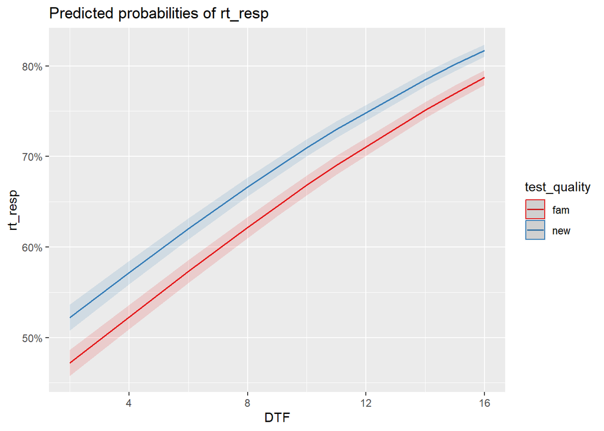

```
## Generalized linear mixed model fit by maximum likelihood (Laplace
##   Approximation) [glmerMod]
##  Family: binomial  ( logit )
## Formula: rt_resp ~ DTAF * test_quality + (1 | workerId)
##    Data: tdlmm
##
##       AIC       BIC    logLik -2*log(L)  df.resid
##    6048.5    6080.9   -3019.3    6038.5      4803
##
## Scaled residuals:
##     Min      1Q  Median      3Q     Max
## -4.5477 -0.9803  0.5038  0.7977  2.0697
##
## Random effects:
##  Groups   Name        Variance Std.Dev.
##  workerId (Intercept) 0.4581   0.6769
## Number of obs: 4808, groups:  workerId, 50
##
## Fixed effects:
##                      Estimate Std. Error z value Pr(>|z|)
## (Intercept)          -2.38188    0.38425  -6.199 5.69e-10 ***
## DTAF                  0.20335    0.02742   7.417 1.20e-13 ***
## test_qualitynew      -0.28880    0.54058  -0.534    0.593
## DTAF:test_qualitynew  0.03461    0.03990   0.868    0.386
## ---
## Signif. codes:  0 '***' 0.001 '**' 0.01 '*' 0.05 '.' 0.1 ' ' 1
##
## Correlation of Fixed Effects:
##             (Intr) DTAF   tst_ql
## DTAF        -0.962
## test_qltynw -0.665  0.681
## DTAF:tst_ql  0.658 -0.684 -0.993
```

```
## Data were 'prettified'. Consider using `terms="DTAF [all]"` to get
##   smooth plots.
```

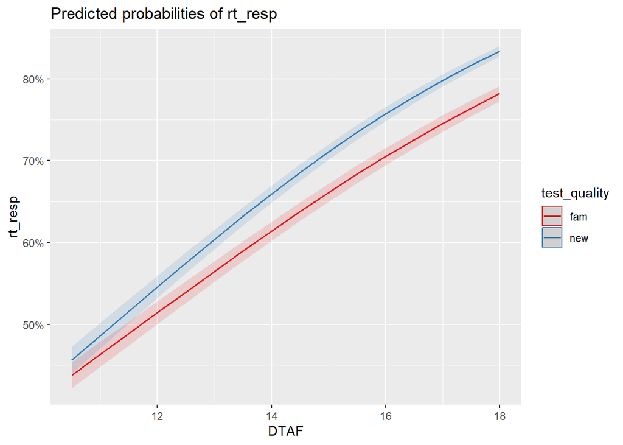

```
## Generalized linear mixed model fit by maximum likelihood (Laplace
##   Approximation) [glmerMod]
##  Family: binomial  ( logit )
## Formula: rt_resp ~ DTAN * test_quality + (1 | workerId)
##    Data: tdlmm
##
##       AIC       BIC    logLik -2*log(L)  df.resid
##    6142.1    6174.5   -3066.0    6132.1      4803
##
## Scaled residuals:
##     Min      1Q  Median      3Q     Max
## -3.2974 -1.0283  0.5395  0.8211  1.8696
##
## Random effects:
##  Groups   Name        Variance Std.Dev.
##  workerId (Intercept) 0.4399   0.6633
## Number of obs: 4808, groups:  workerId, 50
##
## Fixed effects:
##                      Estimate Std. Error z value Pr(>|z|)
## (Intercept)          -1.39080    0.55403  -2.510  0.01206 *
## DTAN                  0.12552    0.03887   3.229  0.00124 **
## test_qualitynew      -0.75711    0.77826  -0.973  0.33064
## DTAN:test_qualitynew  0.06680    0.05548   1.204  0.22860
## ---
## Signif. codes:  0 '***' 0.001 '**' 0.01 '*' 0.05 '.' 0.1 ' ' 1
##
## Correlation of Fixed Effects:
##             (Intr) DTAN   tst_ql
## DTAN        -0.982
## test_qltynw -0.691  0.699
## DTAN:tst_ql  0.688 -0.700 -0.997
## optimizer (Nelder_Mead) convergence code: 0 (OK)
## Model failed to converge with max|grad| = 0.00211352 (tol = 0.002, component 1)
##   See ?lme4::convergence and ?lme4::troubleshooting.
```

```
## Data were 'prettified'. Consider using `terms="DTAN [all]"` to get
##   smooth plots.
```

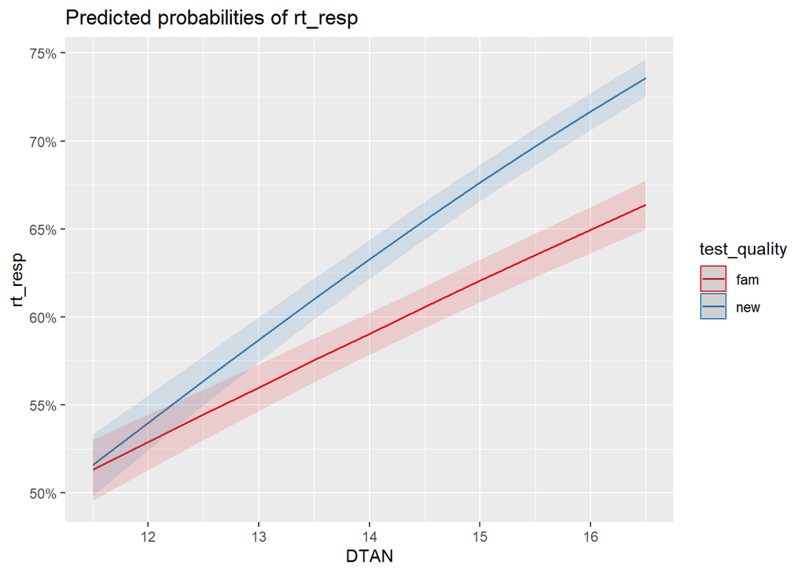

```
## Generalized linear mixed model fit by maximum likelihood (Laplace
##   Approximation) [glmerMod]
##  Family: binomial  ( logit )
## Formula: rt_resp ~ DTN * test_quality + (1 | workerId)
##    Data: tdlmm
##
##       AIC       BIC    logLik -2*log(L)  df.resid
##    6139.1    6171.5   -3064.5    6129.1      4803
##
## Scaled residuals:
##     Min      1Q  Median      3Q     Max
## -3.3994 -1.0280  0.5352  0.8192  1.8806
##
## Random effects:
##  Groups   Name        Variance Std.Dev.
##  workerId (Intercept) 0.4403   0.6636
## Number of obs: 4808, groups:  workerId, 50
##
## Fixed effects:
##                     Estimate Std. Error z value Pr(>|z|)
## (Intercept)         -1.76303    0.58564  -3.010 0.002609 **
## DTN                  0.15798    0.04277   3.694 0.000221 ***
## test_qualitynew     -0.43655    0.81043  -0.539 0.590117
## DTN:test_qualitynew  0.04557    0.06002   0.759 0.447690
## ---
## Signif. codes:  0 '***' 0.001 '**' 0.01 '*' 0.05 '.' 0.1 ' ' 1
##
## Correlation of Fixed Effects:
##             (Intr) DTN    tst_ql
## DTN         -0.984
## test_qltynw -0.703  0.710
## DTN:tst_qlt  0.701 -0.712 -0.997
```

```
## Data were 'prettified'. Consider using `terms="DTN [all]"` to get smooth
##   plots.
```

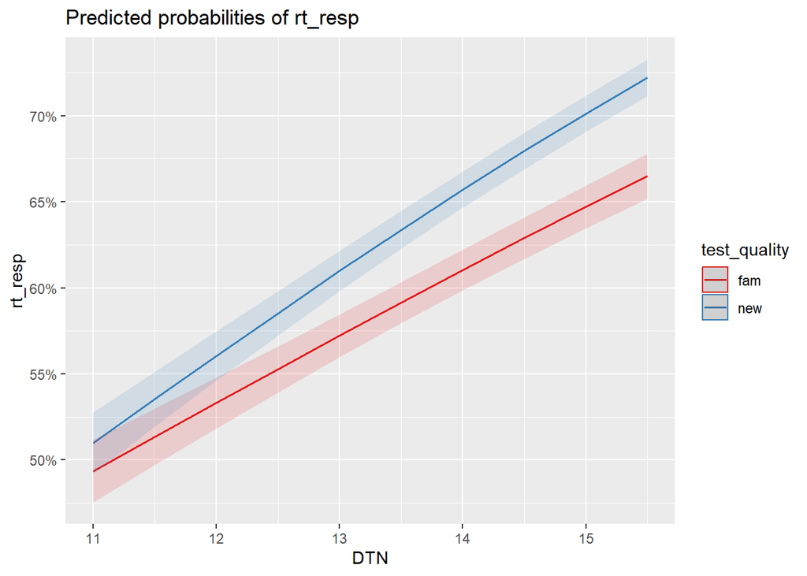

```
## Following indices with missing values are not used for ranking: Sigma
```

```
## # Comparison of Model Performance Indices
##
## Name   |    Model | R2 (cond.) | R2 (marg.) |   ICC |  RMSE | Sigma | Log_loss
## ------------------------------------------------------------------------------
## logmr  | glmerMod |      0.177 |      0.059 | 0.126 | 0.456 |     1 |    0.602
## logmr2 | glmerMod |      0.168 |      0.050 | 0.124 | 0.458 |     1 |    0.606
## logmr3 | glmerMod |      0.153 |      0.035 | 0.122 | 0.461 |     1 |    0.611
## logmr4 | glmerMod |      0.128 |      0.011 | 0.118 | 0.465 |     1 |    0.621
## logmr5 | glmerMod |      0.128 |      0.012 | 0.118 | 0.465 |     1 |    0.621
##
## Name   | Score_log | AIC weights | AICc weights | BIC weights | Performance-Score
## ---------------------------------------------------------------------------------
## logmr  |      -Inf |       1.000 |        1.000 |       0.004 |             -Inf%
## logmr2 |      -Inf |    1.02e-06 |     1.05e-06 |       0.996 |             -Inf%
## logmr3 |      -Inf |    3.14e-18 |     3.21e-18 |    3.06e-12 |             -Inf%
## logmr4 |      -Inf |    1.55e-38 |     1.59e-38 |    1.51e-32 |             -Inf%
## logmr5 |      -Inf |    6.93e-38 |     7.08e-38 |    6.75e-32 |             -Inf%
```

## ALT - Mixed models

Use sum-to-zero contrasts so that coefficients are interpreted as deviations from the grand mean rather than comparisons with the reference level (D1). This is useful when no stimulus type serves as a theoretically meaningful baseline condition.

```
## Generalized linear mixed model fit by maximum likelihood (Laplace
##   Approximation) [glmerMod]
##  Family: binomial  ( logit )
## Formula: rt_resp ~ stimtype * test_quality + (1 | workerId)
##    Data: tdlmm
##
##       AIC       BIC    logLik -2*log(L)  df.resid
##    5967.9    6039.2   -2973.0    5945.9      4797
##
## Scaled residuals:
##     Min      1Q  Median      3Q     Max
## -4.3586 -0.9446  0.4841  0.7939  2.4177
##
## Random effects:
##  Groups   Name        Variance Std.Dev.
##  workerId (Intercept) 0.475    0.6892
## Number of obs: 4808, groups:  workerId, 50
##
## Fixed effects:
##                          Estimate Std. Error z value Pr(>|z|)
## (Intercept)              0.477767   0.102709   4.652 3.29e-06 ***
## stimtype1               -0.642192   0.061752 -10.399  < 2e-16 ***
## stimtype2               -0.159377   0.061803  -2.579  0.00991 **
## stimtype3               -0.002782   0.062553  -0.044  0.96452
## stimtype4                0.022205   0.062216   0.357  0.72116
## test_quality1           -0.093924   0.031649  -2.968  0.00300 **
## stimtype1:test_quality1 -0.004995   0.061529  -0.081  0.93530
## stimtype2:test_quality1  0.088998   0.061783   1.440  0.14973
## stimtype3:test_quality1 -0.197684   0.062570  -3.159  0.00158 **
## stimtype4:test_quality1  0.160907   0.062224   2.586  0.00971 **
## ---
## Signif. codes:  0 '***' 0.001 '**' 0.01 '*' 0.05 '.' 0.1 ' ' 1
##
## Correlation of Fixed Effects:
##             (Intr) stmty1 stmty2 stmty3 stmty4 tst_q1 st1:_1 st2:_1 st3:_1
## stimtype1   -0.016
## stimtype2   -0.011 -0.225
## stimtype3   -0.004 -0.233 -0.235
## stimtype4   -0.006 -0.231 -0.233 -0.238
## test_qulty1 -0.008  0.016  0.011 -0.012  0.019
## stmtyp1:t_1  0.004 -0.002 -0.007  0.005 -0.011 -0.037
## stmtyp2:t_1  0.004 -0.008 -0.008  0.007 -0.009 -0.032 -0.228
## stmtyp3:t_1 -0.005  0.007  0.007 -0.041  0.002 -0.015 -0.233 -0.235
## stmtyp4:t_1  0.007 -0.013 -0.010  0.002  0.006 -0.023 -0.231 -0.232 -0.238
```

## image effects

```
## Generalized linear mixed model fit by maximum likelihood (Laplace
##   Approximation) [glmerMod]
##  Family: binomial  ( logit )
## Formula: rt_resp ~ stimtype * test_quality + (1 | workerId) + (1 | stim)
##    Data: tdlmm
##
##       AIC       BIC    logLik -2*log(L)  df.resid
##    5922.0    5999.8   -2949.0    5898.0      4796
##
## Scaled residuals:
##     Min      1Q  Median      3Q     Max
## -4.6061 -0.9081  0.4628  0.7490  2.4335
##
## Random effects:
##  Groups   Name        Variance Std.Dev.
##  stim     (Intercept) 0.1335   0.3654
##  workerId (Intercept) 0.5036   0.7096
## Number of obs: 4808, groups:  stim, 100; workerId, 50
##
## Fixed effects:
##                           Estimate Std. Error z value Pr(>|z|)
## (Intercept)              0.4899296  0.1117507   4.384 1.16e-05 ***
## stimtype1               -0.6595464  0.0963230  -6.847 7.53e-12 ***
## stimtype2               -0.1643313  0.0962202  -1.708   0.0877 .
## stimtype3                0.0009506  0.0969090   0.010   0.9922
## stimtype4                0.0271981  0.0966222   0.281   0.7783
## test_quality1           -0.0983729  0.0486385  -2.023   0.0431 *
## stimtype1:test_quality1 -0.0059732  0.0961362  -0.062   0.9505
## stimtype2:test_quality1  0.0922221  0.0962046   0.959   0.3378
## stimtype3:test_quality1 -0.2085013  0.0969325  -2.151   0.0315 *
## stimtype4:test_quality1  0.1668039  0.0966289   1.726   0.0843 .
## ---
## Signif. codes:  0 '***' 0.001 '**' 0.01 '*' 0.05 '.' 0.1 ' ' 1
##
## Correlation of Fixed Effects:
##             (Intr) stmty1 stmty2 stmty3 stmty4 tst_q1 st1:_1 st2:_1 st3:_1
## stimtype1   -0.010
## stimtype2   -0.007 -0.239
## stimtype3   -0.002 -0.243 -0.244
## stimtype4   -0.003 -0.242 -0.243 -0.246
## test_qulty1 -0.005  0.009  0.003 -0.006  0.008
## stmtyp1:t_1  0.003  0.002 -0.003  0.001 -0.006 -0.015
## stmtyp2:t_1  0.002 -0.004 -0.006  0.004 -0.003 -0.015 -0.241
## stmtyp3:t_1 -0.004  0.003  0.004 -0.019  0.001 -0.004 -0.244 -0.244
## stmtyp4:t_1  0.004 -0.007 -0.003  0.001  0.003 -0.009 -0.242 -0.243 -0.246
```

```
## $emmeans
## stimtype = D1:
##  test_quality  emmean    SE  df asymp.LCL asymp.UCL
##  fam          -0.2740 0.182 Inf   -0.6308    0.0829
##  new          -0.0653 0.181 Inf   -0.4207    0.2902
##
## stimtype = D2:
##  test_quality  emmean    SE  df asymp.LCL asymp.UCL
##  fam           0.3194 0.182 Inf   -0.0366    0.6754
##  new           0.3317 0.182 Inf   -0.0252    0.6887
##
## stimtype = D3:
##  test_quality  emmean    SE  df asymp.LCL asymp.UCL
##  fam           0.1840 0.182 Inf   -0.1722    0.5402
##  new           0.7978 0.185 Inf    0.4358    1.1597
##
## stimtype = D4:
##  test_quality  emmean    SE  df asymp.LCL asymp.UCL
##  fam           0.5856 0.183 Inf    0.2266    0.9445
##  new           0.4487 0.182 Inf    0.0916    0.8058
##
## stimtype = D5:
##  test_quality  emmean    SE  df asymp.LCL asymp.UCL
##  fam           1.1427 0.187 Inf    0.7759    1.5095
##  new           1.4286 0.192 Inf    1.0526    1.8045
##
## Results are given on the logit (not the response) scale.
## Confidence level used: 0.95
##
## $contrasts
## stimtype = D1:
##  contrast  estimate    SE  df z.ratio p.value
##  fam - new  -0.2087 0.214 Inf  -0.975  0.3298
##
## stimtype = D2:
##  contrast  estimate    SE  df z.ratio p.value
##  fam - new  -0.0123 0.214 Inf  -0.057  0.9542
##
## stimtype = D3:
##  contrast  estimate    SE  df z.ratio p.value
##  fam - new  -0.6137 0.217 Inf  -2.834  0.0046
##
## stimtype = D4:
##  contrast  estimate    SE  df z.ratio p.value
##  fam - new   0.1369 0.216 Inf   0.635  0.5255
##
## stimtype = D5:
##  contrast  estimate    SE  df z.ratio p.value
##  fam - new  -0.2858 0.227 Inf  -1.261  0.2072
##
## Results are given on the log odds ratio (not the response) scale.
```